# Postawy moralne i efekt Knobe’a - raport z badania

## Autor badania: Wiktor Piotrowski

## Cel badania:

Sprawdzenie, w jaki sposób badani interpretują postawę dyrektora wobec szkodzenia i pomagania środowisku oraz jaką sami mają postawę wobec dyrektora.

## Konstrukcja badania:

Badanym przedstawiony były zmodyfikowane (usunięte zostało ostatnie zdanie o skutkach wdrożenia programu) oryginalne Knobe’owskie scenariusze:

**Scenariusz HARM**

Wicedyrektor zwraca się do dyrektora pewnej firmy:

„Myślimy o wdrożeniu nowego programu. Pozwoli nam zwiększyć zyski, ale zaszkodzi środowisku”.

Dyrektor odpowiada:

„Nie obchodzi mnie szkodzenie środowisku. Chcę tylko zwiększyć zyski. Wdrażamy program”.

**Scenariusz HELP**

Wicedyrektor zwraca się do dyrektora pewnej firmy:

„Myślimy o wdrożeniu nowego programu. Pozwoli nam zwiększyć zyski i pomoże środowisku”.

Dyrektor odpowiada:

„Nie obchodzi mnie pomaganie środowisku. Chcę tylko zwiększyć zyski. Wdrażamy program”.

Następnie zostały zadane im dwa pytania:

1. Które zdanie najlepiej opisuje postawę dyrektora?
1. Dyrektor dezaprobuje pomaganie środowisku.
2. Dyrektor aprobuje pomaganie środowisku.
3. Dyrektor dezaprobuje szkodzenie środowisku
4. Dyrektor aprobuje szkodzenie środowisku.
5. Dyrektor jest obojętny wobec środowiska.
2. Jak Pan/Pani ocenia postawę dyrektora?
1. Dezaprobuję postawę dyrektora.
2. Aprobuję postawę dyrektora.
3. Jestem obojętny wobec postawy dyrektora.

## Technikalia

Każdemu z badanych zaprezentowany był tylko jeden scenariusz. Czas na odpowiedź był nieograniczony. Badanie odbyło się za pośrednictwem internetowego systemu ankietowego Limesurvey na platformie uniwersyteckiej Kognilab.

## Wyniki

### Które zdanie najlepiej opisuje postawę dyrektora?

```
##                                  GROUP
## CHAIRMAN_ATTITUDE                 Harm Help
##   0                                  0    0
##   Dyrektor aprobuje szkodzenie       5   16
##   Dyrektor dezaprobuje pomaganie     7    3
##   Dyrektor dezaprobuje szkodzenie    0    1
##   Dyrektor jest obojętny            43   52
```

#### Test istotności statystycznej:

```
##
##  Pearson's Chi-squared test
##
## data:  CHAIRMAN_ATTITUDE and GROUP
## X-squared = 7.0655, df = 3, p-value = 0.06984
```

#### Wykres:

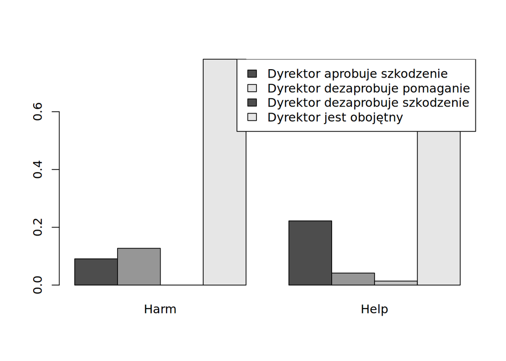

### Jak Pan/Pani ocenia postawę dyrektora?

```
##                                          GROUP
## ATTITUDE                                  Harm Help
##   0                                          0    0
##   Aprobuję postawę dyrektora                 2    2
##   Dezaprobuję postawę dyrektora             41   57
##   Jestem obojętny wobec postawy dyrektora   12   13
```

#### Test istotności statystycznej:

```
##
##  Pearson's Chi-squared test
##
## data:  ATTITUDE and GROUP
## X-squared = 0.38353, df = 2, p-value = 0.8255
```

#### Wykres:

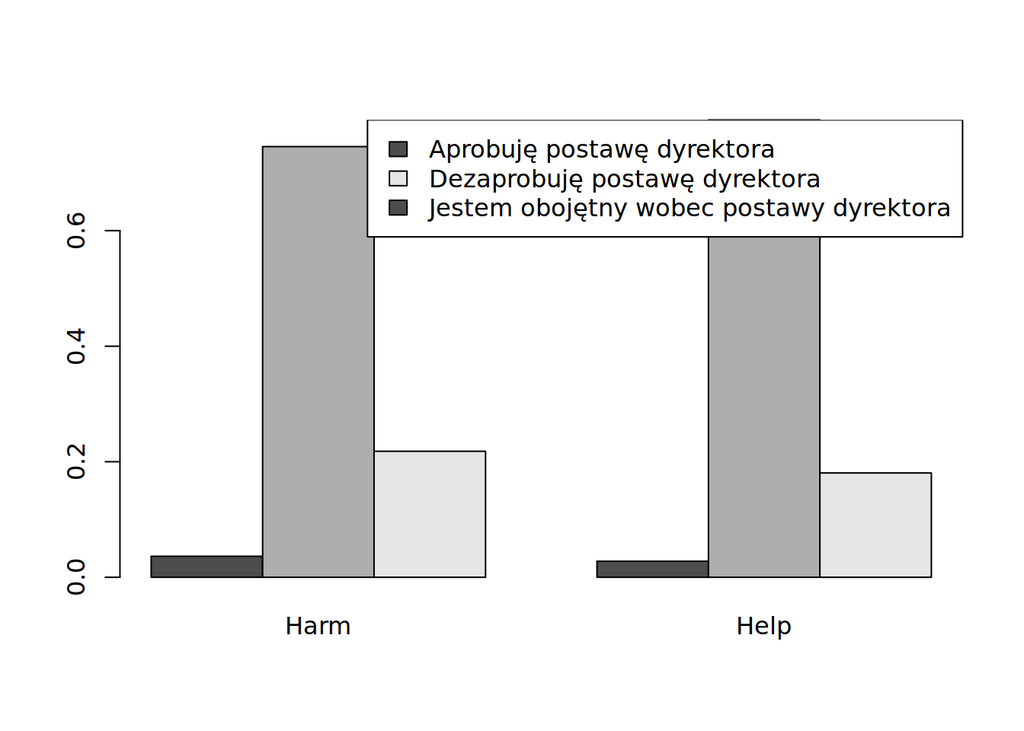